# Analysis of Usage of Smart Devices

Anna Artemova

2022-11-11

# Ask

## Guiding questions

**What is the problem you are trying to solve?**

Bellabeat wants to become a bigger player at the market of smart devices. They want to understand what they need to change in their marketing strategy. They also want to know what are the usage patterns of the users of bigger smart device companies.

**How can your insights drive business decisions?**

I may find out that Bellabeat’s devices lack something that other devices have. I may also identify what may become the special feature of Bellabeat products that should attract more clients. I may also identify if the target groups of other companies are different from what Bellabeat aims to.

## Key tasks

**Identify the business task**

### The business task

- identify how the company can grow and become a bigger player at the smart device market

### Consider key stakeholders

- The two Bellabeat founders, Urška Sršen and Sando Mur are part of executive team.
- The marketing team that analyses the data and suggests marketing strategy.

# Prepare

## The Fitbit dataset

- Daily activity
  - Total steps
  - Total distance
  - Very active distance
  - Moderately active distance
  - Light active distance
  - Sedentary active distance
  - Very active minutes
  - Fairly active minutes
  - Lightly active minutes
  - Sedentary active minutes
  - Calories
- Daily calories
- Hourly calories
- Minute calories (in narrow and wide formats)
- Daily intensities
- Hourly intensities
- Minute intensities (in narrow and wide formats)
- Daily steps
- Hourly steps
- Minute steps (in narrow and wide format)
- Heart rate seconds
- Day sleep
- Minute sleep
- Minute metabolic equivalence (MET)
- Weight Log

The data was recorder during one month from April 12 to May 12, 2016.

### Possible issues

1. The data is not current. They were recorded in 2016, i.e. 6 years ago.
2. These are users that gave their consent to publishing data and they may be different from those who didn’t consent. It is also known that people’s performance is different when they know they are being observed (see Hotorn’s experiment).
3. There is no demographic information on this dataset. It is crucial because Bellabeat produces for women, and the relevance of the results depend on who the people in the Fitbit dataset are.

## Other datasets

I browsed datasets on Kaggle

[Fitness Trackers Products Ecommerce](https://www.kaggle.com/datasets/devsubhash/fitness-trackers-products-ecommerce?datasetId=1703404&sortBy=dateRun&tab=profile) dataset seems very promising at a first glance but it is actually specifically collected on the Indian Market, while the current projects aims at the global market.

Thanks to the Kaggle user Salah who brought into attention another useful dataset in the [discussion forum](https://www.kaggle.com/datasets/arashnic/fitbit/discussion/313589). This dataset contains demographic information and the data was collected 2 years ago. Therefore, this dataset may be useful for the analysis, so I will include it in the project.

I could not find anything relevant on BigQuery Public datasets, Google dataset search, Google Cloud public datasets.

Therefore, the available data seems outdated and one should make conclusions or generalisations cautiously. I would appreciate if someone lets me know about other datasets that I could explore.

# Analysis: FitBit

```r
library(tidyverse)
library(easycsv) # to read multiple .csv files at once
library(lubridate) # to work with dates
```

```r
fitbit <- loadcsv_multi(
  directory = "datasets/Fitabase Data 4.12.16-5.12.16",
  extension = "CSV",
  header = TRUE
)
```

The data about activity only gives the data about users’s behaviour but not about how they use the device. Most of the data is measured automatically, but there are some are put manually. In the current dataset such data is only available for weight log. Let’s look at this data:

## Weight data

### Weight data preprocessing

```r
str(weightLogInfo_merged)
```

```
## 'data.frame':    67 obs. of  8 variables:
##  $ Id            : num  1.50e+09 1.50e+09 1.93e+09 2.87e+09 2.87e+09 ...
##  $ Date          : chr  "5/2/2016 11:59:59 PM" "5/3/2016 11:59:59 PM" "4/13/2016 1:08:52 AM" "4/21/2016 11:59:59 PM" ...
##  $ WeightKg      : num  52.6 52.6 133.5 56.7 57.3 ...
##  $ WeightPounds  : num  116 116 294 125 126 ...
##  $ Fat           : int  22 NA NA NA NA 25 NA NA NA NA ...
##  $ BMI           : num  22.6 22.6 47.5 21.5 21.7 ...
##  $ IsManualReport: chr  "True" "True" "False" "True" ...
##  $ LogId         : num  1.46e+12 1.46e+12 1.46e+12 1.46e+12 1.46e+12 ...
```

Some datatypes are wrong, we fix them:

```r
# create a new dataset to wrangle and save the original one as it is
weight <- weightLogInfo_merged %>%
  mutate(
    IsManualReport_new = case_when(
      IsManualReport == "True" ~ "1",
      TRUE ~ "0"
    ),
    ID_new = as.factor(Id),
    LogId_new = as.factor(LogId),
    date_new = mdy_hms(Date)
  ) %>%
  relocate(IsManualReport_new, .after = IsManualReport) %>% # reorder columns to be able to compare new and old variables
  relocate(ID_new, .after = Id) %>%
  relocate(LogId_new, .after = LogId) %>%
  relocate(date_new, .after = Date)


# Check the variables now

str(weight)
```

```
## 'data.frame':    67 obs. of  12 variables:
##  $ Id                : num  1.50e+09 1.50e+09 1.93e+09 2.87e+09 2.87e+09 ...
##  $ ID_new            : Factor w/ 8 levels "1503960366","1927972279",..: 1 1 2 3 3 4 4 5 5 5 ...
##  $ Date              : chr  "5/2/2016 11:59:59 PM" "5/3/2016 11:59:59 PM" "4/13/2016 1:08:52 AM" "4/21/2016 11:59:59 PM" ...
##  $ date_new          : POSIXct, format: "2016-05-02 23:59:59" "2016-05-03 23:59:59" ...
##  $ WeightKg          : num  52.6 52.6 133.5 56.7 57.3 ...
##  $ WeightPounds      : num  116 116 294 125 126 ...
##  $ Fat               : int  22 NA NA NA NA 25 NA NA NA NA ...
##  $ BMI               : num  22.6 22.6 47.5 21.5 21.7 ...
##  $ IsManualReport    : chr  "True" "True" "False" "True" ...
##  $ IsManualReport_new: chr  "1" "1" "0" "1" ...
##  $ LogId             : num  1.46e+12 1.46e+12 1.46e+12 1.46e+12 1.46e+12 ...
##  $ LogId_new         : Factor w/ 56 levels "1460443631000",..: 39 41 3 20 56 12 43 14 27 38 ...
```

Looks good.

Now I will preserve and rename the new variables and drop the old ones

```r
weight <- weight %>%
  select(-Id, -Date, -IsManualReport, -LogId) %>%
  rename(ID = ID_new,
         date = date_new,
         IsManualReport = IsManualReport_new,
         LogId = LogId_new)
```

Now I check the data integrity.

```r
weight %>%
  duplicated() %>%
  sum()
```

```
## [1] 0
```

No duplicates.

Check missing values:

```r
weight %>%
  gather(variable) %>%
  group_by(variable) %>%
  summarise(NAs = sum(is.na(value)))
```

```
## # A tibble: 8 x 2
##   variable         NAs
##   <chr>          <int>
## 1 BMI                0
## 2 date               0
## 3 Fat               65
## 4 ID                 0
## 5 IsManualReport     0
## 6 LogId              0
## 7 WeightKg           0
## 8 WeightPounds       0
```

65 of 67 observations for Fat are missing

There should be measures of 30 participants. Check how many IDs there are:

```r
weight %>%
  summarise(n_distinct(ID))
```

```
##   n_distinct(ID)
## 1              8
```

### Pattern of tracking use

But for now let’s look at the pattern of using the weight tracking. I will also mark the two observations with fat record.

```r
# if system locale is other than English:
Sys.setlocale("LC_ALL","English")
```

```
## [1] "LC_COLLATE=English_United States.1252;LC_CTYPE=English_United States.1252;LC_MONETARY=English_United States.1252;LC_NUMERIC=C;LC_TIME=English_United States.1252"
```

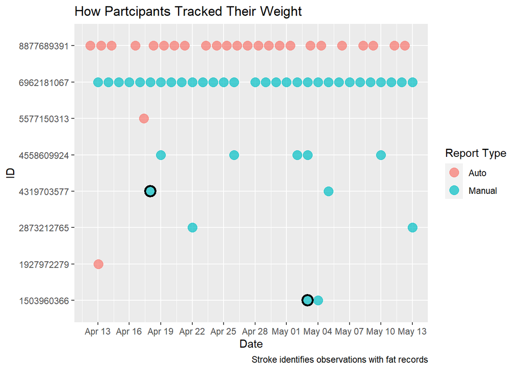

```r
# create a separate dataset with fat records
no_fat_na <- weight %>%
  filter(is.na(Fat)==FALSE)

weight %>%
  ggplot(aes(date, ID))+
  geom_point(aes(color = IsManualReport), alpha = 0.7, size = 4)+
  geom_point(data = no_fat_na, shape = "circle open", size = 4, stroke = 1.5, aplha = 0.7)+
  scale_x_datetime(name = "Date", date_breaks = "3 days", date_labels = "%b %d")+
  scale_color_discrete(name = "Report Type",
                     labels = c("0" = "Auto",
                                "1" = "Manual"))+
  labs(title = "How Partcipants Tracked Their Weight",
       caption = "Stroke identifies observations with fat records")
```

So each users either writes new information manually, or automatically by the tracker but never both. **Most of users do it manually**. Why? Possible explanations: - they do not have weights that automatically send the report to the tracker - they prefer to input manually because it brings them the feeling of a “checkmarked” task

Moreover, the only two fat records are also input manually.

## Tracker usage

We can try to see if there is any difference in what tracker participants use. This can be seen if some participants have records only on some trackers but not on others.

### Limitation

- we don’t know if the default traking options was possible to change
- we don’t know if the user actually used the imformation from tracking

### Data preparation

The Daily Activity dataset already includes Daily Calories, Daily Intensities, and Daily steps, which corresponds to the same number of observations in the four datasets:

```r
dailyActivity_merged %>% count(name = "Daily Activity Dataset")
```

```
##   Daily Activity Dataset
## 1                    940
```

```r
dailyCalories_merged %>% count(name = "Daily Calories Dataset")
```

```
##   Daily Calories Dataset
## 1                    940
```

```r
dailyIntensities_merged %>% count(name = "Daily Intensities Dataset")
```

```
##   Daily Intensities Dataset
## 1                       940
```

```r
dailySteps_merged %>% count(name = "Daily Steps Dataset")
```

```
##   Daily Steps Dataset
## 1                 940
```

Furthermore, there are datasets for heart rate by seconds, minute MET, and daily sleep.

From each dataset I only need IDs.

```r
daily_activity_analysis <- dailyActivity_merged %>%
  select(Id) %>%
  distinct() %>%
  mutate(daily_activity = "1")

heartrate_analysis <- heartrate_seconds_merged %>%
  select(Id) %>%
  distinct() %>%
  mutate(heartrate = "1")

MET_analysis <- minuteMETsNarrow_merged %>%
  select(Id) %>%
  distinct() %>%
  mutate(MET = "1")

sleep_analysis <- dailySteps_merged %>%
  select(Id) %>%
  distinct() %>%
  mutate(sleep = "1")

weight_analysis <- weightLogInfo_merged %>%
  select(Id) %>%
  distinct() %>%
  mutate(weight = "1")

# merge all into one dataset

datasets_by_ids_wide <- daily_activity_analysis %>%
  full_join(heartrate_analysis) %>%
  full_join(MET_analysis) %>%
  full_join(sleep_analysis) %>%
  full_join(weight_analysis) %>%
  mutate(heartrate = as.factor(case_when(is.na(heartrate) == FALSE ~ "1",
         TRUE ~ "0"
         )),
         weight = as.factor(case_when(is.na(weight) == FALSE ~ "1",
         TRUE ~ "0"
         )))
datasets_by_ids_narrow <- datasets_by_ids_wide %>%
  gather("dataset", "using", daily_activity, MET, sleep, heartrate, weight) %>%
  transmute(ID = as.factor(Id),
         dataset = as.factor(dataset),
         using = as.factor(using))
str(datasets_by_ids_narrow)
```

```
## 'data.frame':    165 obs. of  3 variables:
##  $ ID     : Factor w/ 33 levels "1503960366","1624580081",..: 1 2 3 4 5 6 7 8 9 10 ...
##  $ dataset: Factor w/ 5 levels "daily_activity",..: 1 1 1 1 1 1 1 1 1 1 ...
##  $ using  : Factor w/ 2 levels "0","1": 2 2 2 2 2 2 2 2 2 2 ...
```

```r
datasets_by_ids_narrow %>%
  filter(using == "1") %>%
  count(dataset) %>%
  arrange(-n)
```

```
##          dataset  n
## 1 daily_activity 33
## 2            MET 33
## 3          sleep 33
## 4      heartrate 14
## 5         weight  8
```

```r
datasets_by_ids_narrow <- datasets_by_ids_narrow %>%
  filter(dataset != "sleep" & dataset != "MET") %>%
  mutate(dataset = droplevels(recode_factor(dataset, daily_activity = "daily_activity_MET_sleep")))


str(datasets_by_ids_narrow)
```

```
## 'data.frame':    99 obs. of  3 variables:
##  $ ID     : Factor w/ 33 levels "1503960366","1624580081",..: 1 2 3 4 5 6 7 8 9 10 ...
##  $ dataset: Factor w/ 3 levels "daily_activity_MET_sleep",..: 1 1 1 1 1 1 1 1 1 1 ...
##  $ using  : Factor w/ 2 levels "0","1": 2 2 2 2 2 2 2 2 2 2 ...
```

```r
datasets_by_ids_narrow %>%
  filter(using == "1") %>%
  count(dataset) %>%
  arrange(-n)
```

```
##                    dataset  n
## 1 daily_activity_MET_sleep 33
## 2                heartrate 14
## 3                   weight  8
```

Therefore, there are four groups of users:

Can we say that the groups are significantly different from each other?

```r
fit <- glm(using ~ dataset,
           family = "binomial",
           data = datasets_by_ids_narrow)
summary(fit)
```

```
##
## Call:
## glm(formula = using ~ dataset, family = "binomial", data = datasets_by_ids_narrow)
##
## Deviance Residuals:
##      Min        1Q    Median        3Q       Max
## -1.05078  -0.74516   0.00008   0.00008   1.68349
##
## Coefficients:
##                  Estimate Std. Error z value Pr(>|z|)
## (Intercept)         19.57    1872.03   0.010    0.992
## datasetheartrate   -19.87    1872.03  -0.011    0.992
## datasetweight      -20.71    1872.03  -0.011    0.991
##
## (Dispersion parameter for binomial family taken to be 1)
##
##     Null deviance: 136.018  on 98  degrees of freedom
## Residual deviance:  81.542  on 96  degrees of freedom
## AIC: 87.542
##
## Number of Fisher Scoring iterations: 18
```

Even though the difference between the tracking count seems big, we cannot say the numbers are significantly different.

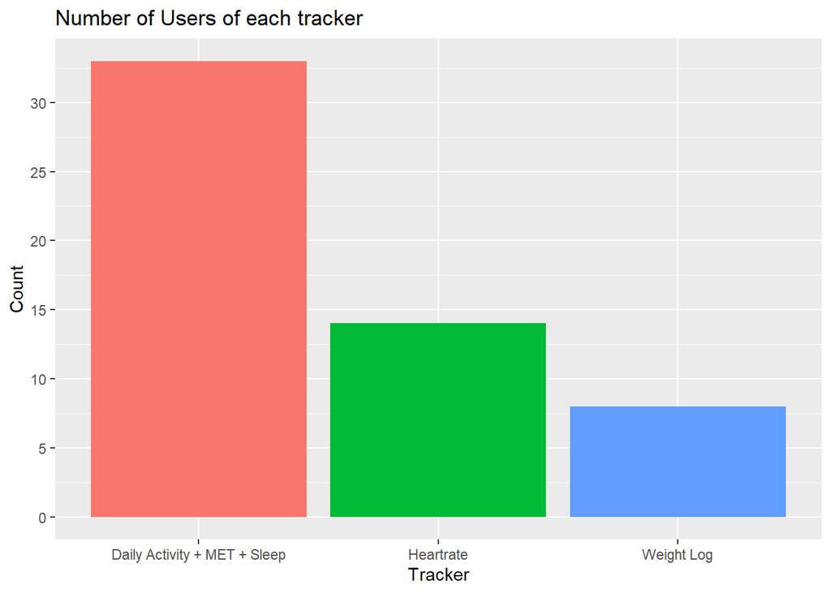

```r
datasets_by_ids_narrow %>%
  filter(using == "1") %>%
  ggplot(aes(dataset))+
  geom_bar(aes(fill = dataset))+
  theme(legend.position = "none")+
  scale_x_discrete(labels = c(daily_activity_MET_sleep = "Daily Activity + MET + Sleep", heartrate = "Heartrate", weight = "Weight Log"))+
  scale_y_continuous(breaks = seq(0,33,5))+
  labs(title = "Number of Users of each tracker",
       x = "Tracker",
       y = "Count")
```